# Regression

Linus Fackler, Fernando Colman

This data set contains information about car sales to predict the price of a car given a set of data. This information contains the price, year, model, odometer reading, and other values. The data set can be found here: https://www.kaggle.com/datasets/deepcontractor/car-price-prediction-challenge

### Load the data & package

```r
library(e1071)
df <- read.csv("car_price_prediction.csv", header = TRUE)
str(df)
```

```
'data.frame':   19237 obs. of  18 variables:
 $ ID              : int  45654403 44731507 45774419 45769185 45809263 45802912 45656768 45816158 45641395 45756839 ...
 $ Price           : int  13328 16621 8467 3607 11726 39493 1803 549 1098 26657 ...
 $ Levy            : chr  "1399" "1018" "-" "862" ...
 $ Manufacturer    : chr  "LEXUS" "CHEVROLET" "HONDA" "FORD" ...
 $ Model           : chr  "RX 450" "Equinox" "FIT" "Escape" ...
 $ Prod..year      : int  2010 2011 2006 2011 2014 2016 2010 2013 2014 2007 ...
 $ Category        : chr  "Jeep" "Jeep" "Hatchback" "Jeep" ...
 $ Leather.interior: chr  "Yes" "No" "No" "Yes" ...
 $ Fuel.type       : chr  "Hybrid" "Petrol" "Petrol" "Hybrid" ...
 $ Engine.volume   : chr  "3.5" "3" "1.3" "2.5" ...
 $ Mileage         : chr  "186005 km" "192000 km" "200000 km" "168966 km" ...
 $ Cylinders       : num  6 6 4 4 4 4 4 4 4 6 ...
 $ Gear.box.type   : chr  "Automatic" "Tiptronic" "Variator" "Automatic" ...
 $ Drive.wheels    : chr  "4x4" "4x4" "Front" "4x4" ...
 $ Doors           : chr  "04-May" "04-May" "04-May" "04-May" ...
 $ Wheel           : chr  "Left wheel" "Left wheel" "Right-hand drive" "Left wheel" ...
 $ Color           : chr  "Silver" "Black" "Black" "White" ...
 $ Airbags         : int  12 8 2 0 4 4 12 12 12 12 ...
```

### Data cleaning

First, we have to clean the data. Some columns are unnecessary, which is why we are going to throw them out. Some contain numbers followed by characters, which is why we have to convert them first to just numbers.

```r
df <- df[, c(2,6,7,8,9,11,12,13,14,15,16,17,18)]
str(df)
```

```
'data.frame':   19237 obs. of  13 variables:
 $ Price           : int  13328 16621 8467 3607 11726 39493 1803 549 1098 26657 ...
 $ Prod..year      : int  2010 2011 2006 2011 2014 2016 2010 2013 2014 2007 ...
 $ Category        : chr  "Jeep" "Jeep" "Hatchback" "Jeep" ...
 $ Leather.interior: chr  "Yes" "No" "No" "Yes" ...
 $ Fuel.type       : chr  "Hybrid" "Petrol" "Petrol" "Hybrid" ...
 $ Mileage         : chr  "186005 km" "192000 km" "200000 km" "168966 km" ...
 $ Cylinders       : num  6 6 4 4 4 4 4 4 4 6 ...
 $ Gear.box.type   : chr  "Automatic" "Tiptronic" "Variator" "Automatic" ...
 $ Drive.wheels    : chr  "4x4" "4x4" "Front" "4x4" ...
 $ Doors           : chr  "04-May" "04-May" "04-May" "04-May" ...
 $ Wheel           : chr  "Left wheel" "Left wheel" "Right-hand drive" "Left wheel" ...
 $ Color           : chr  "Silver" "Black" "Black" "White" ...
 $ Airbags         : int  12 8 2 0 4 4 12 12 12 12 ...
```

We check how many NA rows there are.

```r
sapply(df, function(x) sum(is.na(x)==TRUE))
```

```
           Price       Prod..year         Category Leather.interior        Fuel.type          Mileage        Cylinders
               0                0                0                0                0                0                0
   Gear.box.type     Drive.wheels            Doors            Wheel            Color          Airbags
               0                0                0                0                0                0
```

None, that’s great.

For simplicity reasons, we are going to rename some of the columns, as their names are too unnecessarily long.

```r
names(df)[2] <- "Year"
names(df)[4] <- "Leather"
names(df)[5] <- "Fuel"
names(df)[8] <- "Gearbox"
names(df)[9] <- "Drivetrain"
str(df)
```

```
'data.frame':   19237 obs. of  13 variables:
 $ Price     : int  13328 16621 8467 3607 11726 39493 1803 549 1098 26657 ...
 $ Year      : int  2010 2011 2006 2011 2014 2016 2010 2013 2014 2007 ...
 $ Category  : chr  "Jeep" "Jeep" "Hatchback" "Jeep" ...
 $ Leather   : chr  "Yes" "No" "No" "Yes" ...
 $ Fuel      : chr  "Hybrid" "Petrol" "Petrol" "Hybrid" ...
 $ Mileage   : chr  "186005 km" "192000 km" "200000 km" "168966 km" ...
 $ Cylinders : num  6 6 4 4 4 4 4 4 4 6 ...
 $ Gearbox   : chr  "Automatic" "Tiptronic" "Variator" "Automatic" ...
 $ Drivetrain: chr  "4x4" "4x4" "Front" "4x4" ...
 $ Doors     : chr  "04-May" "04-May" "04-May" "04-May" ...
 $ Wheel     : chr  "Left wheel" "Left wheel" "Right-hand drive" "Left wheel" ...
 $ Color     : chr  "Silver" "Black" "Black" "White" ...
 $ Airbags   : int  12 8 2 0 4 4 12 12 12 12 ...
```

We are going to check, how many unique values the column “Leather” seats has.

```r
unique(df$Leather)
```

```
[1] "Yes" "No"
```

There is no need for further changing this column.

We will need to cut off the “km” after the mileage, to make it into an integer value.

```r
df$Mileage[1:10]
```

```
 [1] "186005 km" "192000 km" "200000 km" "168966 km" "91901 km"  "160931 km" "258909 km" "216118 km" "398069 km" "128500 km"
```

```r
df$Mileage <- gsub(" .*","",df$Mileage)
df$Mileage[1:10]
```

```
 [1] "186005" "192000" "200000" "168966" "91901"  "160931" "258909" "216118" "398069" "128500"
```

Now, we transform it to integer values.

```r
df <- transform(df, Mileage = as.integer(Mileage))
str(df)
```

```
'data.frame':   19237 obs. of  13 variables:
 $ Price     : int  13328 16621 8467 3607 11726 39493 1803 549 1098 26657 ...
 $ Year      : int  2010 2011 2006 2011 2014 2016 2010 2013 2014 2007 ...
 $ Category  : chr  "Jeep" "Jeep" "Hatchback" "Jeep" ...
 $ Leather   : chr  "Yes" "No" "No" "Yes" ...
 $ Fuel      : chr  "Hybrid" "Petrol" "Petrol" "Hybrid" ...
 $ Mileage   : int  186005 192000 200000 168966 91901 160931 258909 216118 398069 128500 ...
 $ Cylinders : num  6 6 4 4 4 4 4 4 4 6 ...
 $ Gearbox   : chr  "Automatic" "Tiptronic" "Variator" "Automatic" ...
 $ Drivetrain: chr  "4x4" "4x4" "Front" "4x4" ...
 $ Doors     : chr  "04-May" "04-May" "04-May" "04-May" ...
 $ Wheel     : chr  "Left wheel" "Left wheel" "Right-hand drive" "Left wheel" ...
 $ Color     : chr  "Silver" "Black" "Black" "White" ...
 $ Airbags   : int  12 8 2 0 4 4 12 12 12 12 ...
```

Let’s check the maximum value of mileage.

```r
max(df$Mileage)
```

```
[1] 2147483647
```

```r
length(df$Mileage[df$Mileage > 500000])
```

```
[1] 258
```

We see that 2147483647 is a very unrealistic number of kilometers. There are 258 observations with a mileage of over 500,000 kilometers, which is why we will throw them out.

```r
df <- df[df$Mileage < 500000,]
```

We can check the same for the price.

```r
max(df$Price)
```

```
[1] 26307500
```

```r
length(df$Price[df$Price > 200000])
```

```
[1] 13
```

These unrealistically high values will negatively impact our data, which is why we will throw everything over 200,000 out.

```r
df <- df[df$Price < 200000,]
```

We will also change Cylinders to integer values.

```r
df <- transform(df, Cylinders = as.integer(Cylinders))
str(df)
```

```
'data.frame':   18963 obs. of  13 variables:
 $ Price     : int  13328 16621 8467 3607 11726 39493 1803 549 1098 26657 ...
 $ Year      : int  2010 2011 2006 2011 2014 2016 2010 2013 2014 2007 ...
 $ Category  : chr  "Jeep" "Jeep" "Hatchback" "Jeep" ...
 $ Leather   : chr  "Yes" "No" "No" "Yes" ...
 $ Fuel      : chr  "Hybrid" "Petrol" "Petrol" "Hybrid" ...
 $ Mileage   : int  186005 192000 200000 168966 91901 160931 258909 216118 398069 128500 ...
 $ Cylinders : int  6 6 4 4 4 4 4 4 4 6 ...
 $ Gearbox   : chr  "Automatic" "Tiptronic" "Variator" "Automatic" ...
 $ Drivetrain: chr  "4x4" "4x4" "Front" "4x4" ...
 $ Doors     : chr  "04-May" "04-May" "04-May" "04-May" ...
 $ Wheel     : chr  "Left wheel" "Left wheel" "Right-hand drive" "Left wheel" ...
 $ Color     : chr  "Silver" "Black" "Black" "White" ...
 $ Airbags   : int  12 8 2 0 4 4 12 12 12 12 ...
```

For some reason, the doors have “May” and “Mar” attached to them. We will get rid of them and change it to integer values.

```r
unique(df$Doors)
```

```
[1] "04-May" "02-Mar" ">5"
```

```r
length(df$Doors[df$Doors == ">5"])
```

```
[1] 125
```

```r
df$Model[df$Doors == ">5"][1:20]
```

[output not shown]

```r
df <- df[!(df$Doors == ">5"),]
```

We are now going to take out the -Mar and -May, and convert it to integer values

```r
df$Doors <- gsub("-.*","",df$Doors)
df$Doors <- gsub("0","",df$Doors)
df$Doors[1:10]
```

```
 [1] "4" "4" "4" "4" "4" "4" "4" "4" "4" "4"
```

```r
df <- transform(df, Doors = as.integer(Doors))
str(df)
```

```
'data.frame':   18838 obs. of  13 variables:
 $ Price     : int  13328 16621 8467 3607 11726 39493 1803 549 1098 26657 ...
 $ Year      : int  2010 2011 2006 2011 2014 2016 2010 2013 2014 2007 ...
 $ Category  : chr  "Jeep" "Jeep" "Hatchback" "Jeep" ...
 $ Leather   : chr  "Yes" "No" "No" "Yes" ...
 $ Fuel      : chr  "Hybrid" "Petrol" "Petrol" "Hybrid" ...
 $ Mileage   : int  186005 192000 200000 168966 91901 160931 258909 216118 398069 128500 ...
 $ Cylinders : int  6 6 4 4 4 4 4 4 4 6 ...
 $ Gearbox   : chr  "Automatic" "Tiptronic" "Variator" "Automatic" ...
 $ Drivetrain: chr  "4x4" "4x4" "Front" "4x4" ...
 $ Doors     : int  4 4 4 4 4 4 4 4 4 4 ...
 $ Wheel     : chr  "Left wheel" "Left wheel" "Right-hand drive" "Left wheel" ...
 $ Color     : chr  "Silver" "Black" "Black" "White" ...
 $ Airbags   : int  12 8 2 0 4 4 12 12 12 12 ...
```

Factorizing all chr data

```r
df$Category <- factor(df$Category)
df$Leather <- factor(df$Leather)
df$Fuel <- factor(df$Fuel)
df$Gearbox <- factor(df$Gearbox)
df$Drivetrain <- factor(df$Drivetrain)
df$Wheel <- factor(df$Wheel)
df$Color <- factor(df$Color)

str(df)
```

```
'data.frame':   18838 obs. of  13 variables:
 $ Price     : int  13328 16621 8467 3607 11726 39493 1803 549 1098 26657 ...
 $ Year      : int  2010 2011 2006 2011 2014 2016 2010 2013 2014 2007 ...
 $ Category  : Factor w/ 11 levels "Cabriolet","Coupe",..: 5 5 4 5 4 5 4 10 10 5 ...
 $ Leather   : Factor w/ 2 levels "No","Yes": 2 1 1 2 2 2 2 2 2 2 ...
 $ Fuel      : Factor w/ 7 levels "CNG","Diesel",..: 3 6 6 3 6 2 3 6 3 6 ...
 $ Mileage   : int  186005 192000 200000 168966 91901 160931 258909 216118 398069 128500 ...
 $ Cylinders : int  6 6 4 4 4 4 4 4 4 6 ...
 $ Gearbox   : Factor w/ 4 levels "Automatic","Manual",..: 1 3 4 1 1 1 1 1 1 1 ...
 $ Drivetrain: Factor w/ 3 levels "4x4","Front",..: 1 1 2 1 2 2 2 2 2 1 ...
 $ Doors     : int  4 4 4 4 4 4 4 4 4 4 ...
 $ Wheel     : Factor w/ 2 levels "Left wheel","Right-hand drive": 1 1 2 1 1 1 1 1 1 1 ...
 $ Color     : Factor w/ 16 levels "Beige","Black",..: 13 2 2 15 13 15 15 8 2 13 ...
 $ Airbags   : int  12 8 2 0 4 4 12 12 12 12 ...
```

### Train and Test sets

Divide into train and test sets

```r
set.seed(1234)
spec <- c(train=.6, test=.2, validate=.2)
i <- sample(cut(1:nrow(df), nrow(df)*cumsum(c(0,spec)), labels=names(spec)))
train <- df[i=="train",]
test <- df[i=="test",]
vald <- df[i=="validate",]
```

### Data Exploration of Training Data

First, we will explore the training data statistically and graphically

```r
print(paste("Number of Rows: ", nrow(train)))
```

```
[1] "Number of Rows:  11302"
```

```r
print(paste("Average price: ", mean(train$Price)))
```

```
[1] "Average price:  17312.4615997169"
```

```r
print(paste("Median price: ", median(train$Price)))
```

```
[1] "Median price:  13328"
```

```r
print(paste("Average mileage: ", mean(train$Mileage)))
```

```
[1] "Average mileage:  135654.299681472"
```

```r
print(paste("Median mileage: ", median(train$Mileage)))
```

```
[1] "Median mileage:  125000"
```

```r
print(paste("Avergae number of airbags: ", mean(train$Airbags)))
```

```
[1] "Avergae number of airbags:  6.58308264024067"
```

```r
print(paste("Median number of airbags: ", median(train$Airbags)))
```

```
[1] "Median number of airbags:  6"
```

This seems like pretty realist data for car sales.

Now, we’ll plot the car price and mileage, to see if there is some obvious correlation.

```r
plot(train$Price ~ train$Mileage, xlab = "Car Mileage", ylab = "Car Price", yaxt = "n", xaxt="n", col = 3, pch = 19)
xTicks = axTicks(1)
yTicks = axTicks(2)
axis(1, at=xTicks, labels = paste(formatC(xTicks / 1000, format = 'd'), 'k', sep = ' '))
```

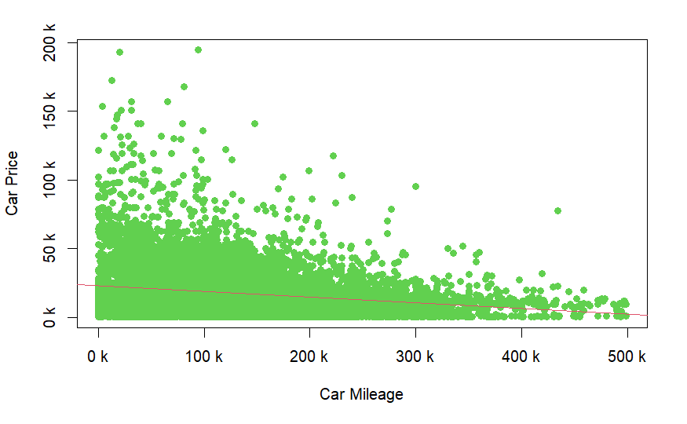

```r
axis(2, at=yTicks, labels = paste(formatC(yTicks / 1000, format = 'd'), 'k', sep = ' '))
abline(lm(train$Price ~ train$Mileage), col = 2)
```

As expected, the price goes down if the mileage goes up. Let’s take a closer look at that.

We will group the cars into their production years.

```r
colors <- c("#2EFF00", #green:  before 1980
            "#FF0000", #red:    between 1980 - 1999
            "#FFFB00", #yellow  between 2000 - 2014
            "#000CFF" #blue     from 2015
           )

yrs <- train$Year
group <- ifelse(yrs < 1980, 1, ifelse(yrs < 2000, 2, ifelse(yrs < 2015, 3, 4)))


plot(train$Price ~ train$Mileage, xlab = "Car Mileage", ylab = "Car Price", yaxt = "n", xaxt="n",  col=colors[group], pch = 19, ylim=c(0,50000))
xTicks = axTicks(1)
yTicks = axTicks(2)
axis(1, at=xTicks, labels = paste(formatC(xTicks / 1000, format = 'd'), 'k', sep = ' '))
```

```r
axis(2, at=yTicks, labels = paste(formatC(yTicks / 1000, format = 'd'), 'k', sep = ' '))
abline(lm(train$Price ~ train$Mileage), col = 1)
```

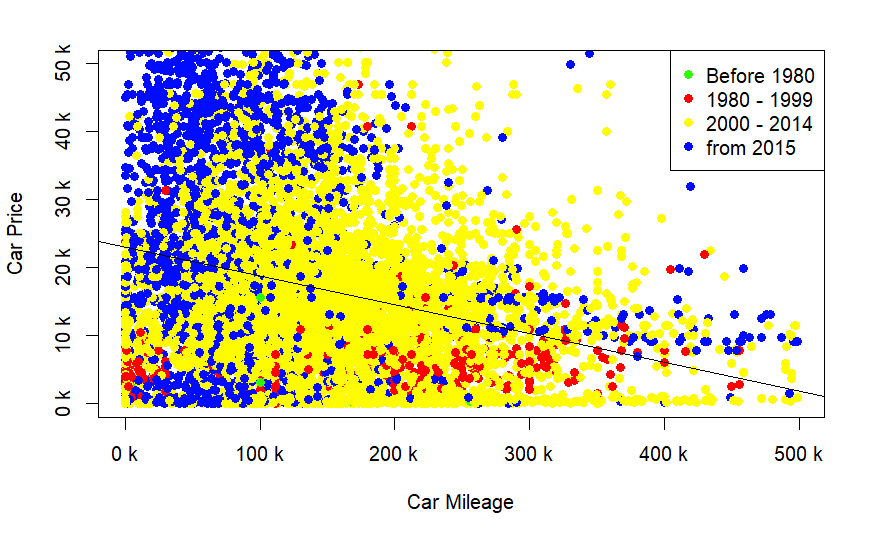

```r
legend("topright", legend=c("Before 1980", "1980 - 1999", "2000 - 2014", "from 2015"), pch = 19, col=colors)
```

```r
length(train$Year[train$Year < 1980])
```

```
[1] 13
```

Now, let’s look at cars with a value of 50 - 200k.

```r
colors <- c("#2EFF00", #green:  before 1980
            "#FF0000", #red:    between 1980 - 1999
            "#FFFB00", #yellow  between 2000 - 2014
            "#000CFF" #blue     from 2015
           )

yrs <- train$Year
group <- ifelse(yrs < 1980, 1, ifelse(yrs < 2000, 2, ifelse(yrs < 2015, 3, 4)))


plot(train$Price ~ train$Mileage, xlab = "Car Mileage", ylab = "Car Price", yaxt = "n", xaxt="n",  col=colors[group], pch = 19, ylim=c(50000,200000))
xTicks = axTicks(1)
yTicks = axTicks(2)
axis(1, at=xTicks, labels = paste(formatC(xTicks / 1000, format = 'd'), 'k', sep = ' '))
```

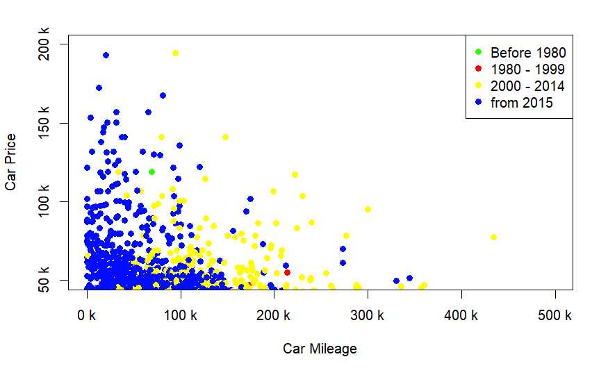

```r
axis(2, at=yTicks, labels = paste(formatC(yTicks / 1000, format = 'd'), 'k', sep = ' '))

legend("topright", legend=c("Before 1980", "1980 - 1999", "2000 - 2014", "from 2015"), pch = 19, col=colors)
```

This section is largely dominated by cars built after 2014.

```r
colors <- c("#2EFF00", #green:  before 1980
            "#FF0000", #red:    between 1980 - 1999
            "#FFFB00", #yellow  between 2000 - 2014
            "#000CFF" #blue     from 2015
           )

yrs <- train$Year
group <- ifelse(yrs < 1980, 1, ifelse(yrs < 2000, 2, ifelse(yrs < 2015, 3, 4)))


plot(train$Price ~ train$Mileage, xlab = "Car Mileage", ylab = "Car Price", yaxt = "n", xaxt="n",  col=colors[group], pch = 19, ylim=c(0,20000))
xTicks = axTicks(1)
yTicks = axTicks(2)
axis(1, at=xTicks, labels = paste(formatC(xTicks / 1000, format = 'd'), 'k', sep = ' '))
```

```r
axis(2, at=yTicks, labels = paste(formatC(yTicks / 1000, format = 'd'), 'k', sep = ' '))
abline(lm(train$Price ~ train$Mileage), col = 1)
```

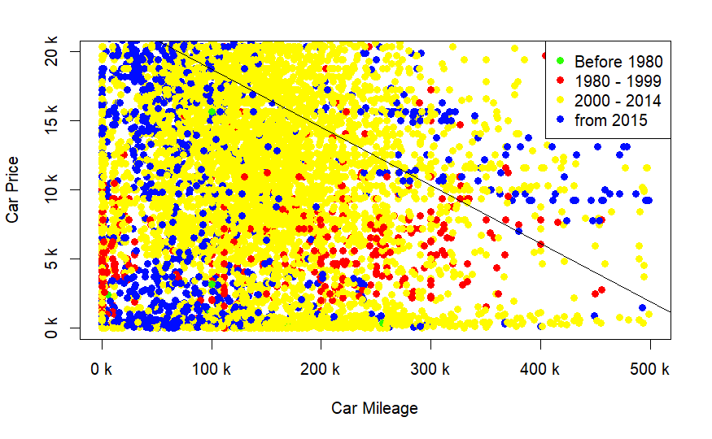

```r
legend("topright", legend=c("Before 1980", "1980 - 1999", "2000 - 2014", "from 2015"), pch = 19, col=colors)
```

This plot shows cars with a price under 20,000. Again, the price goes down the more kilometers it has.

```r
counts <- table(train$Category)
barplot(counts, ylab = "Number of cars", xlab = "", xaxt = "n", col = 4)

axis(1, labels=FALSE)
```

[figure not shown]

```r
text(x = 0:(length(counts) - 1),
     y = -1500,
     labels = paste("     ", names(counts)),
     xpd = NA,
     srt = 35,
     cex = 1.1,
     adj = 0)
```

## Linear Regression

```r
lm1 <- lm(Price~., data=train)
summary(lm1)
```

```
Call:
lm(formula = Price ~ ., data = train)

Residuals:
   Min     1Q Median     3Q    Max
-41074  -8267  -1305   5918 180695

Coefficients:
                        Estimate Std. Error t value Pr(>|t|)
(Intercept)           -2.314e+06  7.194e+04 -32.167  < 2e-16 ***
Year                   1.160e+03  3.589e+01  32.317  < 2e-16 ***
CategoryCoupe         -3.453e+03  3.517e+03  -0.982 0.326198
CategoryGoods wagon   -1.193e+04  3.725e+03  -3.202 0.001369 **
CategoryHatchback     -9.096e+03  3.493e+03  -2.604 0.009231 **
CategoryJeep          -1.178e+03  3.487e+03  -0.338 0.735438
CategoryLimousine      2.268e+04  6.180e+03   3.670 0.000243 ***
CategoryMicrobus      -6.638e+03  3.679e+03  -1.804 0.071211 .
CategoryMinivan       -3.640e+03  3.563e+03  -1.022 0.306981
CategoryPickup         3.429e+03  4.524e+03   0.758 0.448468
CategorySedan         -9.624e+03  3.474e+03  -2.771 0.005605 **
CategoryUniversal     -1.592e+03  3.627e+03  -0.439 0.660646
LeatherYes            -4.626e+02  4.034e+02  -1.147 0.251469
FuelDiesel             4.544e+03  9.963e+02   4.561 5.15e-06 ***
FuelHybrid            -4.258e+03  1.023e+03  -4.162 3.18e-05 ***
FuelHydrogen          -8.295e+03  1.491e+04  -0.556 0.578082
FuelLPG               -4.164e+02  1.207e+03  -0.345 0.730231
FuelPetrol            -1.171e+03  9.509e+02  -1.231 0.218300
FuelPlug-in Hybrid     8.055e+03  2.332e+03   3.455 0.000553 ***
Mileage               -2.749e-02  1.713e-03 -16.052  < 2e-16 ***
Cylinders              1.558e+03  1.506e+02  10.347  < 2e-16 ***
GearboxManual          5.627e+03  6.932e+02   8.117 5.27e-16 ***
GearboxTiptronic       1.208e+04  4.222e+02  28.613  < 2e-16 ***
GearboxVariator        7.193e+03  7.905e+02   9.099  < 2e-16 ***
DrivetrainFront        2.347e+03  4.727e+02   4.964 6.99e-07 ***
DrivetrainRear         3.698e+03  6.036e+02   6.126 9.31e-10 ***
Doors                  5.248e+02  4.693e+02   1.118 0.263505
WheelRight-hand drive -2.918e+03  6.178e+02  -4.723 2.36e-06 ***
ColorBlack             6.361e+00  1.736e+03   0.004 0.997076
ColorBlue             -1.321e+03  1.788e+03  -0.739 0.459977
ColorBrown             1.733e+03  2.215e+03   0.782 0.434057
ColorCarnelian red    -5.286e+02  2.264e+03  -0.233 0.815425
ColorGolden            1.653e+03  2.320e+03   0.712 0.476187
ColorGreen             5.683e+02  2.047e+03   0.278 0.781320
ColorGrey              8.759e+02  1.760e+03   0.498 0.618758
ColorOrange            1.793e+03  2.365e+03   0.758 0.448350
ColorPink              1.476e+03  5.041e+03   0.293 0.769722
ColorPurple           -2.964e+03  3.746e+03  -0.791 0.428836
ColorRed              -2.085e+03  1.876e+03  -1.112 0.266258
ColorSilver           -1.195e+03  1.740e+03  -0.687 0.492186
ColorSky blue          2.171e+03  2.435e+03   0.891 0.372704
ColorWhite             2.125e+02  1.738e+03   0.122 0.902674
ColorYellow            1.246e+03  2.465e+03   0.506 0.613153
Airbags               -5.237e+02  3.690e+01 -14.192  < 2e-16 ***
---
Signif. codes:  0 ‘***’ 0.001 ‘**’ 0.01 ‘*’ 0.05 ‘.’ 0.1 ‘ ’ 1

Residual standard error: 14870 on 11258 degrees of freedom
Multiple R-squared:  0.2985,    Adjusted R-squared:  0.2958
F-statistic: 111.4 on 43 and 11258 DF,  p-value: < 2.2e-16
```

```r
pred <- predict(lm1, newdata = test)
cor_lm1 <- cor(pred, test$Price)
mse_lm1 <- mean((pred - test$Price) ^2)

print(paste("cor=", cor_lm1))
```

```
[1] "cor= 0.525781076156056"
```

```r
print(paste("mse=", mse_lm1))
```

```
[1] "mse= 193424474.691449"
```

## Linear Kernel

We will have to use smaller data samples, otherwise my computer won’t be able to compute the following models. SVM with 11000 observations takes about 8 minutes. Tuning couldn’t even finish, it reached the maximum number of iterations.

```r
trainsmall <- head(train, 2000)
testsmall <- head(test, 500)
valdsmall <- head(vald, 500)
svm1 <- svm(Price~., data=trainsmall, kernel="linear", cost=10, scale=TRUE)
summary(svm1)
```

```
Call:
svm(formula = Price ~ ., data = trainsmall, kernel = "linear", cost = 10, scale = TRUE)


Parameters:
   SVM-Type:  eps-regression
 SVM-Kernel:  linear
       cost:  10
      gamma:  0.02272727
    epsilon:  0.1


Number of Support Vectors:  1681
```

```r
pred <- predict(svm1, newdata=testsmall)
cor_svm1 <- cor(pred, testsmall$Price)
mse_svm1 <- mean((pred - testsmall$Price) ^2)
print(paste("cor=", cor_svm1))
```

```
[1] "cor= 0.523067369892093"
```

```r
print(paste("mse=", mse_svm1))
```

```
[1] "mse= 168603894.790165"
```

### Tune

```r
tune_svm1 <- tune(svm, Price~. , data=valdsmall, kernel="linear", ranges=list(cost=c(0.001, 0.01, 0.1, 1, 5, 10, 100)))
summary(tune_svm1)
```

```
Parameter tuning of ‘svm’:

- sampling method: 10-fold cross validation

- best parameters:
```

|  | cost |
| --- | --- |
|  | 0.1 |

```
- best performance: 243940906

- Detailed performance results:
```

| cost | error | dispersion |
| --- | --- | --- |
| 1e-03 | 291937015 | 116926804 |
| 1e-02 | 255949493 | 98456449 |
| 1e-01 | 243940906 | 87934321 |
| 1e+00 | 250391135 | 84300344 |
| 5e+00 | 251851422 | 84202646 |
| 1e+01 | 251873175 | 84248854 |
| 1e+02 | 252067005 | 84415121 |

```
NA
```

### Evaluate on best linear svm

```r
pred <- predict(tune_svm1$best.model, newdata = testsmall)
cor_svm1_tune <- cor(pred, testsmall$Price)
mse_svm1_tune <- mean((pred - testsmall$Price) ^2)
print(paste("cor=", cor_svm1_tune))
```

```
[1] "cor= 0.514899488912912"
```

```r
print(paste("mse=", mse_svm1_tune))
```

```
[1] "mse= 176416898.639076"
```

## Polynomial Kernel

```r
svm2 <- svm(Price~., data=trainsmall, kernel="polynomial", cost=10, scale = TRUE)
summary(svm2)
```

```
Call:
svm(formula = Price ~ ., data = trainsmall, kernel = "polynomial", cost = 10, scale = TRUE)


Parameters:
   SVM-Type:  eps-regression
 SVM-Kernel:  polynomial
       cost:  10
     degree:  3
      gamma:  0.02272727
     coef.0:  0
    epsilon:  0.1


Number of Support Vectors:  1577
```

```r
pred <- predict(svm2, newdata = testsmall)
cor_svm2 <- cor(pred, testsmall$Price)
mse_svm2 <- mean((pred - testsmall$Price) ^2)
print(paste("cor=", cor_svm2))
```

```
[1] "cor= 0.630556779356833"
```

```r
print(paste("mse=", mse_svm2))
```

```
[1] "mse= 144990455.730843"
```

### Tune

```r
tune_svm2 <- tune(svm, Price~. , data=valdsmall, kernel="polynomial", ranges=list(cost=c(0.001, 0.01, 0.1, 1, 5, 10, 100)))
summary(tune_svm2)
```

```
Parameter tuning of ‘svm’:

- sampling method: 10-fold cross validation

- best parameters:
```

|  | cost |
| --- | --- |
|  | 100 |

```
- best performance: 217526268

- Detailed performance results:
```

| cost | error | dispersion |
| --- | --- | --- |
| 1e-03 | 319828545 | 135639203 |
| 1e-02 | 319637010 | 135674464 |
| 1e-01 | 316947218 | 135426001 |
| 1e+00 | 303763925 | 134085896 |
| 5e+00 | 282324724 | 132090562 |
| 1e+01 | 270214054 | 131115711 |
| 1e+02 | 217526268 | 103418515 |

```
NA
```

```r
pred <- predict(tune_svm2$best.model, newdata = testsmall)
cor_svm2_tune <- cor(pred, testsmall$Price)
mse_svm2_tune <- mean((pred - testsmall$Price) ^2)
print(paste("cor=", cor_svm2_tune))
```

```
[1] "cor= 0.474380238754904"
```

```r
print(paste("mse=", mse_svm2_tune))
```

```
[1] "mse= 237326314.430851"
```

## Radial Kernel

```r
svm3 <- svm(Price~., data=trainsmall, kernel="radial", cost=10, scale=TRUE)
summary(svm3)
```

```
Call:
svm(formula = Price ~ ., data = trainsmall, kernel = "radial", cost = 10, scale = TRUE)


Parameters:
   SVM-Type:  eps-regression
 SVM-Kernel:  radial
       cost:  10
      gamma:  0.02272727
    epsilon:  0.1


Number of Support Vectors:  1545
```

```r
pred <- predict(svm3, newdata = testsmall)
cor_svm3 <- cor(pred, testsmall$Price)
mse_svm3 <- mean((pred - testsmall$Price) ^2)
print(paste("cor=", cor_svm3))
```

```
[1] "cor= 0.695253196627123"
```

```r
print(paste("mse=", mse_svm3))
```

```
[1] "mse= 121875946.04193"
```

### Tune hyperperameters

```r
set.seed(1234)
tune.out <- tune(svm, Price~., data=valdsmall, kernel="radial", ranges=list(cost=c(0.1,1,10,100,1000), gamma=c(0.5,1,2,3,4)))
summary(tune.out)
```

```
Parameter tuning of ‘svm’:

- sampling method: 10-fold cross validation

- best parameters:
```

|  | cost | gamma |
| --- | --- | --- |
|  | 10 | 0.5 |

```
- best performance: 231031179

- Detailed performance results:
```

| cost | gamma | error | dispersion |
| --- | --- | --- | --- |
| 1e-01 | 0.5 | 283015990 | 136824406 |
| 1e+00 | 0.5 | 231051545 | 108956205 |
| 1e+01 | 0.5 | 231031179 | 95218483 |
| 1e+02 | 0.5 | 260025782 | 87163389 |
| 1e+03 | 0.5 | 326759443 | 107199292 |
| 1e-01 | 1.0 | 298952988 | 139496002 |
| 1e+00 | 1.0 | 264247251 | 126884496 |
| 1e+01 | 1.0 | 261324505 | 107294508 |
| 1e+02 | 1.0 | 281453741 | 115982248 |
| 1e+03 | 1.0 | 291186053 | 119750273 |

[output cut: 15 more lines]

```
NA
```

```r
svm4 <- svm(Price~., data=trainsmall, kernel="radial", cost=10, gamma=0.5, scale=TRUE)
summary(svm4)
```

```
Call:
svm(formula = Price ~ ., data = trainsmall, kernel = "radial", cost = 10, gamma = 0.5, scale = TRUE)


Parameters:
   SVM-Type:  eps-regression
 SVM-Kernel:  radial
       cost:  10
      gamma:  0.5
    epsilon:  0.1


Number of Support Vectors:  1556
```

```r
pred <- predict(svm4, newdata = testsmall)
cor_svm4 <- cor(pred, testsmall$Price)
mse_svm4 <- mean((pred - testsmall$Price) ^2)
print(paste("cor=", cor_svm4))
```

```
[1] "cor= 0.728147563806647"
```

```r
print(paste("mse=", mse_svm4))
```

```
[1] "mse= 110893534.092218"
```

## Analysis

The Radial Kernel with tuned hyperparameters will give us the best result of 0.72 correlation. The second best was the polynomial kernel with 0.63, and third was the linear kernel with 0.52. Linear Regression was as good as the linear kernel SVM.

Looking at the data provided, it was obvious that the radial kernel would outperform the other ones. The data is very cluttered and is not at all linearly separable. This is why the linear kernel didn’t work well. The polynomial was definitely better, but still couldn’t perfectly handle our messy data.

Therefore, the radial was best in this case. With a very big difference to the linear regression.